# Minimal Advice on Programming in R

36-402

January 25, 2016

# Style

- You *will* comment your code
  - Comment every function with purpose, inputs, outputs
- You *will* use meaningful names
- You *will* indent code blocks (Control-I)

  ```r
  # Calculate quantiles of the Pareto distribution
  # Inputs: desired quantile (p)
    # exponent of the distribution (exponent)
    # lower threshold of the distribution (threshold)
  # Outputs: the pth quantile
  qpareto.1 <- function(p, exponent, threshold) {
    q <- threshold*((1-p)^(-1/(exponent-1)))
    return(q)
  }
  ```

- You *ought* to avoid calling your main data set `data`
  - vague
  - already the name of a function for loading data sets from packages
  - often the name of arguments in e.g. model-fitting functions
  - both of those make it hard to trace what’s going on

  ```r
  #Excerpt from HW1 solutions
  data <- read.csv("http://www.stat.cmu.edu/~cshalizi/uADA/16/hw/01/CAPA.csv")
  value.median.mean <- lm(Median_house_value ~ Median_household_income
                      + Mean_household_income, data=data)
  ```

  - Makes you feel crazy

**A treat:** The following is code from a prominent statistician:

```r
### CENSORED TO PROTECT THE INNOCENT ###
```

# Functions

- Use functions to tie together related commands so they can be repeated

  *Example:* Suppose that we want to easily compute the quantiles of the Pareto distribution. The density function is: $f(x;\alpha,x_0) = \begin{cases} \frac{\alpha-1}{x_0}\left(\frac{x}{x_0}\right)^{-\alpha} & x \ge x_0\\ 0 & x < x_0 \end{cases}$ and the quantile function is $Q(p; \alpha,x_0) = x_0(1-p)^{-\frac{1}{\alpha-1}}$

  ```r
  # Calculate quantiles of the Pareto distribution
  # Inputs: desired quantile (p)
    # exponent of the distribution (exponent)
    # lower threshold of the distribution (threshold)
  # Outputs: the pth quantile
  qpareto.1 <- function(p, exponent, threshold) {
    q <- threshold*((1-p)^(-1/(exponent-1)))
    return(q)
  }
  ```

  Then instead of

  ```r
  # alpha = 2.33, x_0 = 6e8, p = 0.5
  6e8 * (1-0.5)^(-1/(2.33-1))
  ```

  ```
  ## [1] 1010391288
  ```

  ```r
  # alpha = 2.33, x_0 = 6e8, p = 0.4
  6e8 * (1-0.4)^(-1/(2.33-1))
  ```

  ```
  ## [1] 880957225
  ```

  ```r
  # alpha = 2.5, x_0 = 1e6, p = 0.92
  1e6 * (1-0.92)^(-1/(2.5-1))
  ```

  ```
  ## [1] 5386087
  ```

  we can say

  ```r
  qpareto.1(p=0.5, exponent=2.33, threshold=6e8)
  ```

  ```
  ## [1] 1010391288
  ```

  ```r
  qpareto.1(p=0.4, exponent=2.33, threshold=6e8)
  ```

  ```
  ## [1] 880957225
  ```

  ```r
  qpareto.1(p=0.92, exponent=2.5, threshold=1e6)
  ```

  ```
  ## [1] 5386087
  ```

  Much harder to make mistakes!
- Arguments: what does the function need to know?
  - Default values let you omit arguments that don’t change often
  - Default values can always be over-ridden

  ```r
  # Calculate quantiles of the Pareto distribution
  # Inputs: desired quantile (p)
    # exponent of the distribution (exponent)
    # lower threshold of the distribution (threshold)
    # flag for whether to give lower or upper quantiles (lower.tail)
  # Outputs: the pth quantile
  qpareto.2 <- function(p, exponent, threshold, lower.tail=TRUE) {
    if(lower.tail==FALSE) {
  p <- 1-p
    }
    q <- threshold*((1-p)^(-1/(exponent-1)))
    return(q)
  }

  qpareto.2(p=0.92, exponent=2.5, threshold=1e6)
  ```

  ```
  ## [1] 5386087
  ```

  ```r
  qpareto.2(p=0.92, exponent=2.5, threshold=1e6, lower.tail=FALSE)
  ```

  ```
  ## [1] 1057162
  ```

  - No-argument functions can be useful for simulation

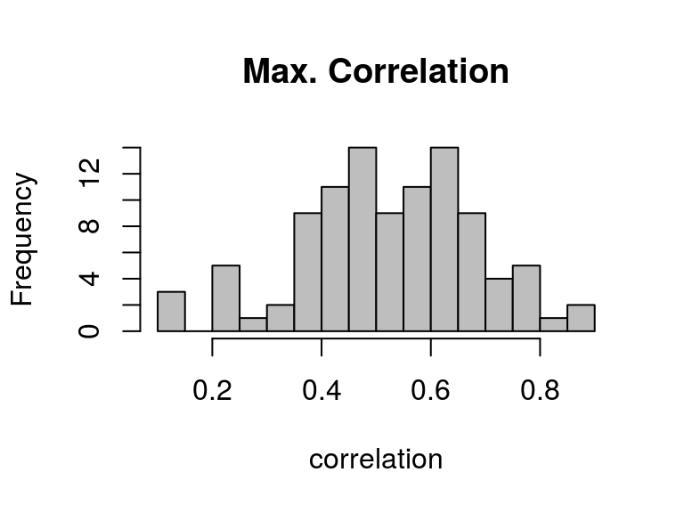

  ```r
  # (Unrelated to the quantile functions)
  # Function to return the biggest correlation of 5 length-10 Gaussian vectors
  # Takes no arguments, so it can be used in a simulation
  random.correlation.max = function(){
    #Draw a 10x5 matrix of Gaussians
    X = matrix(rnorm(50),nrow=10,ncol=5)
    #Compute the correlation matrix
    cor.matrix = cor(X)
    #Find the biggest entry, making sure to avoid the diagonal (which is all 1)
    return(max(cor.matrix[upper.tri(cor.matrix)]))
  }

  #Draw 100 samples and plot them
  hist(replicate(100,random.correlation.max()),20,col='grey', main="Max. Correlation",xlab='correlation')
  ```

  - `...` indicates pass-through arguments. You won’t use this very often, but many `R` functions do.
- Return value
  - Try to be explicit about what you return
  - Use `c()` or `list()` to return more than one thing (We will see some examples of this)

# When should we write functions?

- When we’re repeating the same thing multiple times
- When we’re writing very similar code over and over
- When we’re breaking down a big job into smaller ones
- When we’re told to

**Example:** From Solutions to Homework 1. You were asked to make several maps of your residuals. The following function was modified from last term.

```r
# Set up a function to make maps
  # "Terrain" color-levels set based on quantiles of the variable being plotted
# Inputs: vector to be mapped over the data frame; number of levels to
  # use for colors; name of the longitude coordinate; name of the lattitude
  # coordinate; data frame to take coordinates from; other plotting arguments
# Outputs: invisibly, list giving cut-points and the level each observation
  # was assigned
mapper <- function(z, levels, x="LONGITUDE", y="LATITUDE", data,
                   legend.loc="topright", ncol=1, ...) {
    # Which quantiles do we need?
    probs <- seq(from=0, to=1, length.out=(levels+1))
    # What are those quantiles?
    z.quantiles <- quantile(z, probs)
    # Assign each observation to its quantile
    z.categories <- cut(z, z.quantiles, include.lowest=TRUE)
    # Make up a color scale
    shades <- terrain.colors(levels)
    plot(x=data[,x], y=data[,y], col=shades[z.categories], ...)
    legend(x=legend.loc, legend=levels(z.categories), col=shades,
           ncol=ncol, pch=19)
    invisible(list(quantiles=z.quantiles, categories=z.categories))
}
```

# Chaining functions together

- Divide the big job (“come up with a confidence band”) into smaller parts
- Write a function for each part
- Make sure the outputs of the early steps can be used as inputs to the later steps
- Recurse if need be: the sub-functions spawn sub-sub-functions, etc.
- We can often re-use the sub-functions (e.g., `resample()`)

**Example** I work on a statistics problem in inference for networks/graphs. Suppose that I want to run a hypothesis test about an edge in the graph. I might need:

- A function that carries out the test. It calls:
  - A function that can draw a sample from a particular null distribution. It calls:
    - A function that can check the validity of a particular sample.

This is helpful for many reasons:

- Many different tests use this null distribution
- The validity check shows up in many other problems
- I can debug each piece individually, starting from the bottom
- I can have a set of tests for each piece, so I notice when I break it

# Calling functions from other functions

It is often convenient to call functions from other functions, as we build functionality. As a simple example, we could have avoided replicating the quantile code from `qpareto.1` in `qpareto.2` as follows.

```r
# Calculate quantiles of the Pareto distribution
# Inputs: desired quantile (p)
  # exponent of the distribution (exponent)
  # lower threshold of the distribution (threshold)
  # flag for whether to give lower or upper quantiles (lower.tail)
# Outputs: the pth quantile
qpareto.3 <- function(p, exponent, threshold, lower.tail=TRUE) {
  if(lower.tail==FALSE) {
    p <- 1-p
  }
  q <- qpareto.1(p, exponent, threshold)
  return(q)
}
```

This calls `qpareto.1` to do the actual calculation, after making corrections for the `lower.tail` argument.

This is very useful! You will often be working with several intertwined functions at the same time. We should be very careful to understand what happens.

A *very* simple example:

```r
# A very simple function that adds one to its argument
add.one = function(x){
  x+1
}

# A function that calls add.one to do its addition
add.stuff = function(x){
  return(add.one(x))
}

# See? We can add!
add.stuff(3)
```

```
## [1] 4
```

```r
# A terrible job rewriting add.one
add.one = function(x){
  x+2
}

#Now what?
add.stuff(3)
```

```
## [1] 5
```

The `add.stuff` function looks for `add.one` each time it is called. If `add.one` has changed, it uses the new version of the function. It does not save a snapshot at the time `add.stuff` is defined.

This is great, since it lets you easily edit all your functions and have the changes propagate. However, you do need to be aware and careful.

# Debugging

Eventually, you will break something.

- **Problem**: the final piece of code you write gives an incomprehensible error message
- **Idea**: Carefully characterize the bug, then narrow down where it could be until the the problem is obvious.
- Strategy: make sure all the lower-level pieces are working properly
  - Start debugging from the bottom
  - If all the small bits work on their own, the bug comes when you put them together
- Use test cases
  - “What should this do if it works?”
  - “What should this *not* do if it’s broken?”
- When you meet a new bug, write a new test
  - “How do I know if this is fixed?”
  - Test could be very minimal: “It runs without crashing”
- `traceback()`: Show all the calls leading to the last error
  - Look for the last line of code you wrote
  - This helps localize where things went wrong
- `browser()`: A convenient way to mess around inside a function -When called within a function, gives you an R shell there -Avoids problems with local variables disappearing
- A favorite line: Executes `[Dangerous Expression]` and calls `browser()` if there is an error. Great for seeing problems that only happen sometimes inside of for loops inside of functions.

  ```r
  tryCatch({[Dangerous Expression]},warning=function(w){browser()},
       error=function(e){browser()})
  ```

**Example:** Suppose that I want to sample a Pareto random variable. I know that if $F(x)$ is the CDF for a distribution and $U$ is a uniform random variable, then $F^{-1}(U)$ has the F distribution.

First, for good practice, define a version of the quantile function that validates inputs

```r
# Calculate quantiles of the Pareto distribution
# Inputs: desired quantile (p)
  # exponent of the distribution (exponent)
  # lower threshold of the distribution (threshold)
  # flag for whether to give lower or upper quantiles (lower.tail)
# Outputs: the pth quantile
qpareto.4 <- function(p, exponent, threshold, lower.tail=TRUE) {
  #browser()
  stopifnot(p >= 0, p <= 1, exponent > 1, threshold > 0)
  q <- qpareto.3(p,exponent,threshold,lower.tail)
  return(q)
}
```

```r
#Try it with a bad input
qpareto.4(p=0.92,exponent=2.5,threshold=-1,lower.tail=FALSE)
```

Now we can define a random pareto function. This version is (intentionally) buggy!

```r
# Generate random numbers from the Pareto distribution
# Inputs: number of random draws (n)
  # exponent of the distribution (exponent)
  # lower threshold of the distribution (threshold)
# Outputs: vector of random numbers
rpareto <- function(n,exponent,threshold) {
  x <- vector(length=n)
  for (i in 1:n) {
    x[i] <- qpareto.4(p=runif(1),exponent=exponent,threshold=threshold)
  }
  return(x)
}
```

We can run it and get an error

```r
# If we run this block in Rmarkdown, it will break our document
# Run this in an R session.
rpareto(10)
rpareto(n=10,exponent=2.5,threshold=1)
```

# Avoid iteration

- Iterating in R is often quite slow
- R has lots of ways to avoid iteration
- This is often faster! And easier to follow!

Compare:

```r
# Generate random numbers from the Pareto distribution
# Inputs: number of random draws (n)
  # exponent of the distribution (exponent)
  # lower threshold of the distribution (threshold)
# Outputs: vector of random numbers
rpareto.1 <- function(n,exponent,threshold) {
  x <- vector(length=n)
  for (i in 1:n) {
    x[i] <- qpareto.4(p=runif(1),exponent=exponent,threshold=threshold)
  }
  return(x)
}

# Generate random numbers from the Pareto distribution
# Inputs: number of random draws (n)
  # exponent of the distribution (exponent)
  # lower threshold of the distribution (threshold)
# Outputs: vector of random numbers
rpareto.2 <- function(n,exponent,threshold) {
  x = replicate(n, qpareto.4(p=runif(1),exponent=exponent,threshold=threshold))
  return(x)
}

system.time(rpareto.1(10000,exponent=2.5,threshold=1))
```

```
##    user  system elapsed
##   0.243   0.000   0.243
```

```r
system.time(rpareto.2(10000,exponent=2.5,threshold=1))
```

```
##    user  system elapsed
##   0.377   0.000   0.409
```

We could try vectorizing our function better:

```r
#Our `qpareto1` functions can handle vector `p` arguments just fine.
qpareto.4(c(.1,.2,.3), 2.5, 1)
```

```
## [1] 1.072766 1.160397 1.268434
```

```r
# Generate random numbers from the Pareto distribution
# Inputs: number of random draws (n)
  # exponent of the distribution (exponent)
  # lower threshold of the distribution (threshold)
# Outputs: vector of random numbers
rpareto.3 <- function(n,exponent,threshold) {
  x = qpareto.4(p=runif(n), exponent=exponent, threshold=threshold)
  return(x)
}
system.time(rpareto.3(10000,exponent=2.5,threshold=1))
```

```
##    user  system elapsed
##   0.003   0.000   0.002
```

**Other approaches to removing iteration**

- use `ifelse` to do conditional things to entire vectors

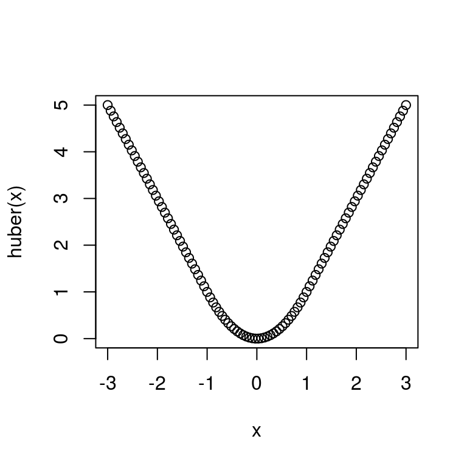

  ```r
  # Calculate Huber's loss function
  # Input: vector of numbers x
  # Return: x^2 for |x|<1, 2|x|-1 otherwise
  huber <- function(x) {
    return(ifelse(abs(x) <= 1, x^2, 2*abs(x)-1))
  }
  x = seq(from=-3,to=3,length.out=100)
  plot(x,huber(x))
  ```

- use matrix operations

  ```r
  # Get some long vectors
  n = 100000
  a = rnorm(n)
  b = rnorm(n)
  # Find the inner product with a for loop
  system.time({
  total = 0
  for(i in 1:length(a)){total = total + a[i]*b[i]}
  })
  ```

  ```
  ##    user  system elapsed
  ##   0.140   0.000   0.153
  ```

  ```r
  # Find the inner product with matrix operations
  system.time({
  a %*% b #R handles vector dimensions in a funny way here.  Read ?matmult
  })
  ```

  ```
  ##    user  system elapsed
  ##   0.001   0.000   0.001
  ```

- use vector arithmetic

  ```r
  # Get some long vectors
  n = 100000
  a = rnorm(n)
  b = rnorm(n)

  # Find the sum with a for loop, don't preallocate memory
  system.time({
  total = numeric(0) #Don't actually allocate any space
  for(i in 1:length(a)){total[i] = a[i]+b[i]}
  })
  ```

  ```
  ##    user  system elapsed
  ##  21.871   0.016  21.983
  ```

  ```r
  # Find the sum with a for loop, allocate memory all at once
  system.time({
  total = numeric(n) #Allocate space ahead of time
  for(i in 1:length(a)){total[i] = a[i]+b[i]}
  })
  ```

  ```
  ##    user  system elapsed
  ##   0.183   0.000   0.183
  ```

  ```r
  # Find the inner product with matrix operations
  system.time({
  a + b #R handles vector dimensions in a funny way here.  Read ?matmult
  })
  ```

  ```
  ##    user  system elapsed
  ##   0.000   0.000   0.001
  ```

- use `apply` to apply a function to rows or columns of a matrix. Use `sapply` to apply a function to every element of a vector.

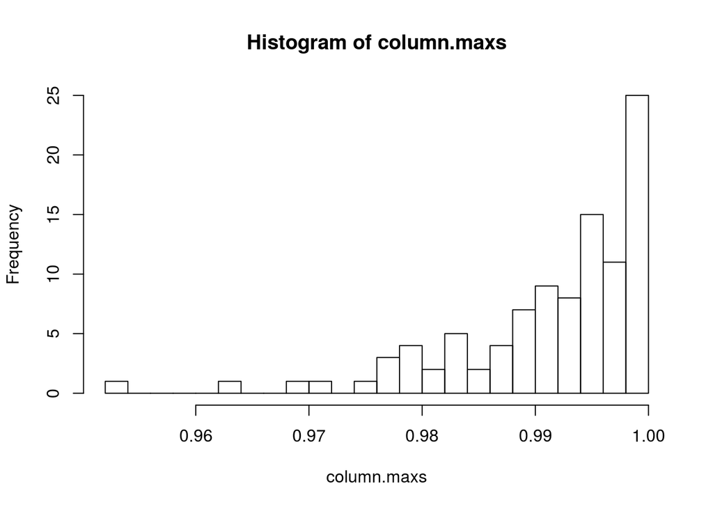

  ```r
  #Make a 100x100 matrix of uniform [0,1] variables
  X = matrix(runif(10000),nrow=100,ncol=100)
  #Find the maximum of each column
  column.maxs = apply(X, MARGIN = 2, FUN = max)
  #Plot a histogram.  Do you know the distribution?
  hist(column.maxs,20)
  ```

**A sidenote on matrix arithmetic and subsetting**

When subsetting a matrix, we expect R to return another matrix.

```r
#Make a matrix
X = matrix(rnorm(12),nrow=4,ncol=3)
X
```

```
##            [,1]       [,2]        [,3]
## [1,] -1.5156656 -0.7527156  0.27717781
## [2,]  0.3802144  0.8397816 -0.90298396
## [3,]  0.5414839 -0.7360646  0.06724232
## [4,]  0.2960943 -0.7469858  0.45159979
```

```r
#We would expect the following to all return 3x3 matrices
t(X) %*% X
```

```
##            [,1]       [,2]       [,3]
## [1,]  2.8226820  0.8404169 -0.5933096
## [2,]  0.8404169  2.3715927 -1.3537787
## [3,] -0.5933096 -1.3537787  1.1006715
```

```r
t(X[1:3,]) %*% X[1:3,]
```

```
##            [,1]      [,2]       [,3]
## [1,]  2.7350101  1.061595 -0.7270257
## [2,]  1.0615951  1.813605 -1.0164401
## [3,] -0.7270257 -1.016440  0.8967291
```

```r
t(X[1:2,]) %*% X[1:2,]
```

```
##            [,1]       [,2]       [,3]
## [1,]  2.4418053  1.4601622 -0.7634363
## [2,]  1.4601622  1.2718139 -0.9669454
## [3,] -0.7634363 -0.9669454  0.8922076
```

```r
t(X[1,]) %*% X[1,]
```

```
##          [,1]
## [1,] 2.940651
```

What went wrong?

```r
    dim(X)
```

```
## [1] 4 3
```

```r
    dim(X[1:2,])
```

```
## [1] 2 3
```

```r
    dim(X[1,])
```

[output not shown]

When we choose a subset with at least one dimension 1, R drops those dimensions! For a 2-D matrix, this becomes a 1-D vector! Many functions treat a vector very differently.

```r
dim(X)
```

```
## [1] 4 3
```

```r
length(X)
```

```
## [1] 12
```

```r
dim(X[,1])
```

[output not shown]

```r
length(X[,1])
```

```
## [1] 4
```

To fix this, we can specify that the additional dimension should not be dropped.

```r
dim(X[,1,drop=FALSE])
```

```
## [1] 4 1
```

```r
length(X[,1,drop=FALSE])
```

```
## [1] 4
```

```r
t(X[1,,drop=FALSE]) %*% X[1,,drop=FALSE]
```

```
##            [,1]       [,2]        [,3]
## [1,]  2.2972423  1.1408652 -0.42010889
## [2,]  1.1408652  0.5665808 -0.20863607
## [3,] -0.4201089 -0.2086361  0.07682754
```

# Do not be afraid of iteration

- Some jobs are just inherently iterative
- Use it when that’s what you need to do
- If you’re storing stuff as you go, create the variables which you’re storing into outside the loop

```r
sim.ar <- function(n,x1,phi=0,sd=1) {
  x <- vector(length=n)
  x[1] <- x1
  for (t in 2:n) {
    x[t] <- phi*x[t-1]+rnorm(1,mean=0,sd=sd)
  }
  return(x)
}
```

# Returning vectors and lists

A function can return one *thing*. Often you want to return more than one value. - For several values of the same type, you can return a vector - For several different sorts of values, you can return a list. You can even assign names!

For an example of returning a list, we return to the random correlation matrix example

```r
# Function to return the correlation matrix of 5 length-10 Gaussian vectors
random.correlation.matrix = function(){
  #Draw a 10x5 matrix of Gaussians
  X = matrix(rnorm(50),nrow=10,ncol=5)
  #Compute the correlation matrix
  cor.matrix = cor(X)
  cor.matrix
}
#Function to compute summaries of a correlation matrix
matrix.extremes = function(M){
  #Extract the off-diagonal entries
  off.diagonal = M[upper.tri(M)]
  #Return the largest and smallest off-diagonal entries
  return(list(max = max(off.diagonal), min = min(off.diagonal)))
}
matrix.extremes(random.correlation.matrix())
```

```
## $max
## [1] 0.6462206
##
## $min
## [1] -0.6484274
```

```r
replicate(5,matrix.extremes(random.correlation.matrix()))
```

```
##     [,1]       [,2]       [,3]       [,4]       [,5]
## max 0.5685958  0.5498803  0.4050465  0.4095796  0.729471
## min -0.3054157 -0.2361346 -0.5031285 -0.6958686 -0.3911191
```

For an example of returning a vector, we look at our rpareto function from earlier:

```r
# Generate random numbers from the Pareto distribution
# Inputs: number of random draws (n)
  # exponent of the distribution (exponent)
  # lower threshold of the distribution (threshold)
# Outputs: vector of random numbers
rpareto.3 <- function(n,exponent,threshold) {
  x = qpareto.4(p=runif(n), exponent=exponent, threshold=threshold)
  return(x) #If n>1, this is a vector!
}

#This will return a vector of 10 things:
rpareto.3(10,2.5,1)
```

```
##  [1] 1.022777 1.287552 1.280614 2.908297 2.329300 2.340561 2.386480
##  [8] 2.973543 1.347765 2.358582
```